# p8105_hw5_ps3070

```r
library(tidyverse)
library(knitr)
```

## Problem 1

```r
set.seed(10)

iris_with_missing = iris %>%
  map_df(~replace(.x, sample(1:150, 20), NA)) %>%
  mutate(Species = as.character(Species))

is.list(iris_with_missing) #confirmed that it is a list
```

```
## [1] TRUE
```

There are two cases to address:

For numeric variables, you should fill in missing values with the mean of non-missing values

For character variables, you should fill in missing values with “virginica”

Write a function that takes a vector as an argument; replaces missing values using the rules defined above; and returns the resulting vector. Apply this function to the columns of iris_with_missing using a map statement.

```r
replace_iris_missing = function(a) {
  if (is.numeric(a)) {
    b = mean(a, na.rm = TRUE) #creating new variable for means
    a = replace(a, is.na(a), b) #replacing na values in a with means from b
  } else if (is.character(a)) {
    a = replace(a, is.na(a), "virginica") #replacing character na values
  }
}

output = map_df(iris_with_missing, replace_iris_missing) #maps function to each vector

output #to check that it worked
```

```
## # A tibble: 150 x 5
##    Sepal.Length Sepal.Width Petal.Length Petal.Width Species
##           <dbl>       <dbl>        <dbl>       <dbl> <chr>
##  1         5.1          3.5         1.4         0.2  setosa
##  2         4.9          3           1.4         0.2  setosa
##  3         4.7          3.2         3.84        0.2  virginica
##  4         4.6          3.1         1.5         0.2  virginica
##  5         5            3.6         1.4         1.24 setosa
##  6         5.4          3.9         1.7         1.24 setosa
##  7         5.88         3.4         1.4         0.3  setosa
##  8         5            3.4         1.5         0.2  setosa
##  9         4.4          2.9         1.4         0.2  setosa
## 10         4.9          3.1         1.5         0.1  setosa
## # … with 140 more rows
```

```r
head(output) %>%
  kable()
```

| Sepal.Length | Sepal.Width | Petal.Length | Petal.Width | Species |
| --- | --- | --- | --- | --- |
| 5.1 | 3.5 | 1.400000 | 0.200000 | setosa |
| 4.9 | 3.0 | 1.400000 | 0.200000 | setosa |
| 4.7 | 3.2 | 3.836923 | 0.200000 | virginica |
| 4.6 | 3.1 | 1.500000 | 0.200000 | virginica |
| 5.0 | 3.6 | 1.400000 | 1.243846 | setosa |
| 5.4 | 3.9 | 1.700000 | 1.243846 | setosa |

## Problem 2

This dataset contains data from a longitudinal study that included a control arm and an experimental arm. Data for each participant is included in a separate file, and file names include the subject ID and arm.

Create a tidy dataframe containing data from all participants, including the subject ID, arm, and observations over time:

Start with a dataframe containing all file names; the list.files function will help

```r
names = tibble(
  file_names = list.files(path = "./data") #creating vector file_names
  )

names #created a df with file names called names
```

```
## # A tibble: 20 x 1
##    file_names
##    <chr>
##  1 con_01.csv
##  2 con_02.csv
##  3 con_03.csv
##  4 con_04.csv
##  5 con_05.csv
##  6 con_06.csv
##  7 con_07.csv
##  8 con_08.csv
##  9 con_09.csv
## 10 con_10.csv
## 11 exp_01.csv
## 12 exp_02.csv
## 13 exp_03.csv
## 14 exp_04.csv
## 15 exp_05.csv
## 16 exp_06.csv
## 17 exp_07.csv
## 18 exp_08.csv
## 19 exp_09.csv
## 20 exp_10.csv
```

There are 10 patients in the control arm and 10 patients in the experimental arm. These file names are now stored in one column in the `names` data frame.

```r
get_data = function(x) {

  {directory = "./data/"
  data = read.csv(paste(directory, x, sep = ""))}

  return(data)
}
```

Iterate over file names and read in data for each subject using purrr::map and saving the result as a new variable in the dataframe

Tidy the result; manipulate file names to include control arm and subject ID, make sure weekly observations are “tidy”, and do any other tidying that’s necessary

```r
tidy_df = names %>%
  mutate(obs = map(file_names, get_data)) %>%
  unnest(obs) %>%
  janitor::clean_names() %>%
  separate(file_names, into = c("arm", "subject"), sep = "_") %>%
  mutate(subject = str_replace(subject, ".csv", "")) %>%
  gather(key = week, value = meas, week_1:week_8) %>%
  separate(week, into = c("extra", "week"), sep = "_") %>%
  select(-extra) %>%
  mutate(arm = as.character(arm),
         subject = as.factor(subject),
         week = as.numeric(week)) %>%
  arrange(arm)

head(tidy_df) %>%
  kable(format = "html", caption = "Study Measurements") #tibble sorted by week
```

Study Measurements

| arm | subject | week | meas |
| --- | --- | --- | --- |
| con | 01 | 1 | 0.20 |
| con | 02 | 1 | 1.13 |
| con | 03 | 1 | 1.77 |
| con | 04 | 1 | 1.04 |
| con | 05 | 1 | 0.47 |
| con | 06 | 1 | 2.37 |

Make a spaghetti plot showing observations on each subject over time, and comment on differences between groups.

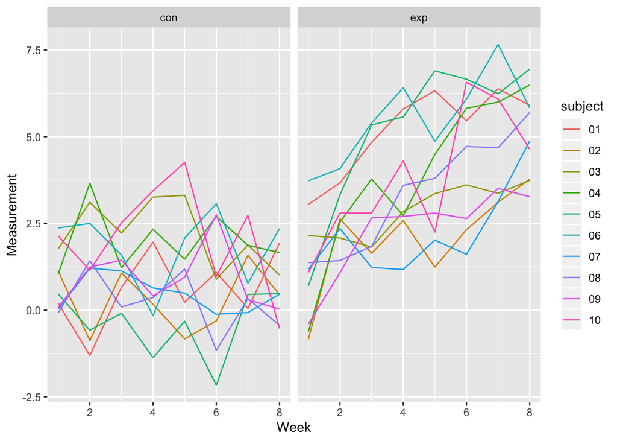

```r
files_plot = tidy_df %>%
  ggplot(aes(x = week, y = meas, color = subject)) +
  geom_line() +
  facet_grid(~arm) +
  labs(x = "Week",
       y = "Measurement")

files_plot
```

## Problem 3

First, I set the following design elements:

```r
n = 30
x_i1 = rnorm(n, 0, 1) #x draws from standard normal dist
beta_0 = 2
sd = 50

beta_1 = 0
```

Then, I am generating 10,000 datasets from the following model:

$$y_i = \beta_0 + \beta_1 x_{i1} + \epsilon_{i}$$